# Aside

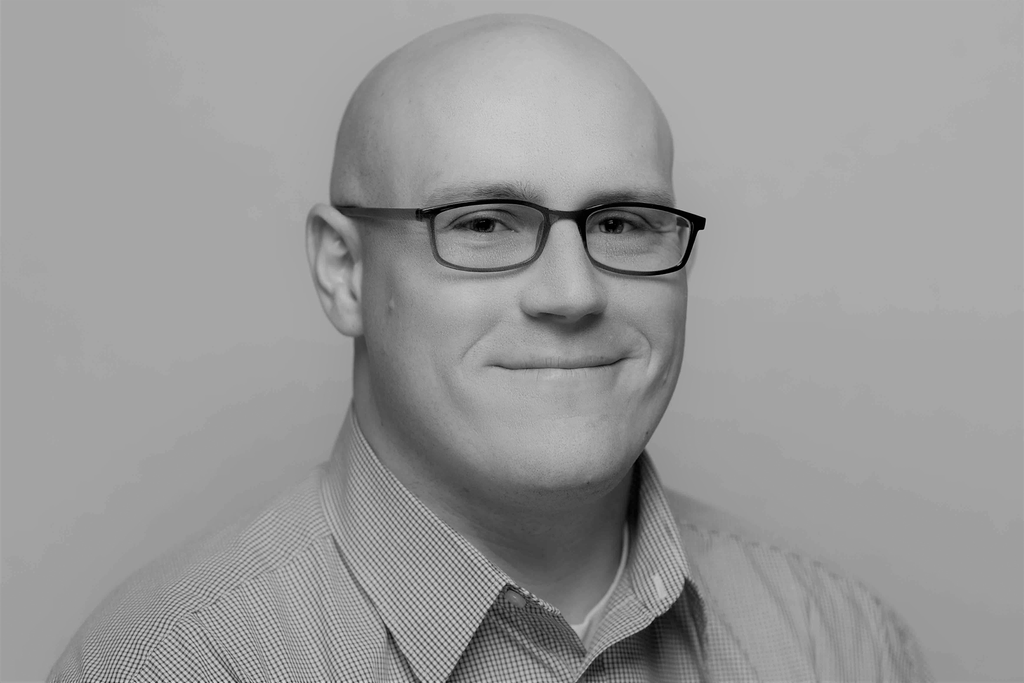

[Download a PDF of this CV](https://github.com/nuhorchak/resume/blob/master/pdfs/uhorchak_cv.pdf)

## Contact

- nuhorchak@gmail.com
- nuhorchak
- github.com/nuhorchak/
- nuhorchak.github.io/
- linkedin.com/in/nicholas-uhorchak/

## Language Skills

Python

Julia

R

SQL

Neo4j/Cypher

MongoDB

PowerBI

DataRobot

VBA

## Disclaimer

Made with the R package [**pagedown**](https://github.com/rstudio/pagedown).

The source code is available [on github.com/nuhorchak/resume](https://github.com/nuhorchak/resume).

Last updated on 2025-10-30.

# Main

## Nick Uhorchak

PhD Student at the University Of Arkansas, Department of Industrial Engineering. Army ORSA, having served in various roles from budget analyst, to data scientist, at Joint and Army level commands.

## Education

### Ph.D., Industrial Engineering

University of Arkansas

Fayetteville, Arkansas

2027 - 2023

- PhD candidate, focusing on deterministic and stochastic optimization.

### M.S., Operations Research

Air Force Instituite of Technology

Wright Patterson AFB, OH

2018 - 2016

- Thesis: An Analysis of Incomplete SOCOM Selection Data (Distribution Statement D).

### B.S., Information Technology

United States Military Academy

West Point, NY

2008 - 2004

- Selected as one of three MVPs during execution of the Cyber Defense Exercise, for performance as team leader in the larger group project

## Industry Experience

### Data Scientist

U.S. Army

Various

2023 - 2018

- Data Scientist in various roles across the United Stated Army, ranging from budget analysis to optimization and predictive modeling.

### ORSA / Data Scientist

US Special Operations Command (SOCOM)

MacDill AFB, FL

2021 - 2018

- Data Science (R1J) qualified Operations Research Systems Analyst, serving as an data scientist in a combatant command headquarters.
- Responsible for multiple data science efforts, including predictive, prescriptive and statistical modeling

## Selected Publications, Posters, and Talks

Academic presentations and publications

### Pediatric Vaccine Tender Scheduling with purchasing quantity discounts

N/A

Planned Publication

2025

### Pediatric Vaccine Tender Scheduling in Low and Middle Income Countries

https://arxiv.org/abs/2403.07755

IISE Conference Proceedings

2024

### Long Term Pediatric Vaccine Tender Scheduling

Atlanta, GA

IISE Annual Conference

2025

### From Data to Decisions: Pediatric Vaccine Tender Scheduling

Atlanta, GA

INFORMS Annual Conference

2025

### Vaccine Tender Scheduling and Procurement: A Taxonomic Review

https://www.sciencedirect.com/science/article/abs/pii/B9780443289934001529?via%3Dihub

Encyclopedia in Operations Management

2024

### Pediatric Vaccine Tender Scheduling in Low and Middle Income Countries

Little Rock, AR

Arkansas Bioinformatis Consortium

2024

### Pediatric Vaccine Tender Scheduling in Low and Middle Income Countries

Montreal, Canada

IISE Annual Conference

2024

### Pediatric Tender Scheduling Under Uncertainty

Seattle, WA

INFORMS Annual Conference

2024

## Honors Received

Academic achievements

### Alpha Pi Mu Honor Society

Industrial Engineering

University of Arkansas

2024

- Inducted into Alpha Pi Mu, for distinguished graduate achievement.

### John S.W. Fargher Scholarship

IISE

University of Arkansas

2024

- IISE Scholarship Winner

### R1J (Data Science) PDSI

US Army

US Army

2019

- Awarded the Personnel Development Skill Identifier (PDSI) R1J for Data Science

### Omega Rho Honor Society

INFORMS

AFIT

2018

- Inducted into Omega Rho Honor Society for academic excellence through GPA greater than 3.75